# Machine learning Project : Personal Loan Campaign

## Data Preprocessing

### Data Preparation for Modeling

### Outlier Detection

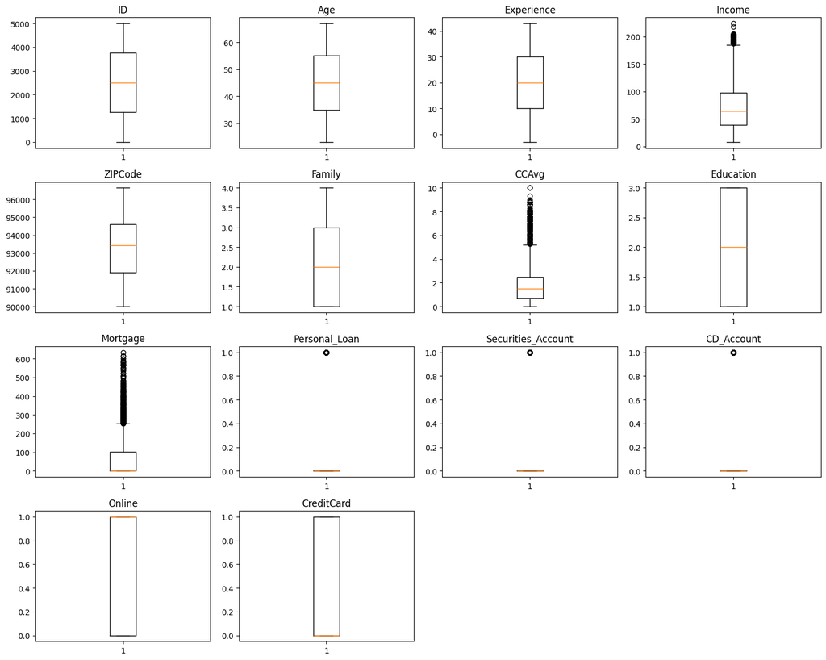

```python
# outlier detection using boxplot

# Selects numerical columns from the DataFrame `data` using `select_dtypes(include=np.number)` and converts the column names to a list.
numeric_columns = data.select_dtypes(include=np.number).columns.tolist()
# Creates a new figure and a set of subplots with a specified figure size.
plt.figure(figsize=(15, 12))
# Loops through the list of numerical column names and their index.
for i, variable in enumerate(numeric_columns): #Iterate through each column
    # Creates a subplot in the current figure. The layout is 4 rows by 4 columns, and the current subplot is at position i + 1.
    plt.subplot(4, 4, i + 1)
    # Generates a box plot for the current numerical variable. `whis=1.5` sets the length of the whiskers.
    plt.boxplot(data[variable], whis=1.5) # plot the boxplot
    # Adjusts subplot parameters for a tight layout.
    plt.tight_layout()
    # Sets the title of the current subplot to the name of the variable.
    plt.title(variable)
# Displays the plots.
plt.show()
```

Observations

- There are quite a few outliers in the data.
- However, we will not treat them as they are proper values

**Creating training and test sets.**

```python
# encoding the categorical variables

# X will contain all columns except 'Personal_Loan', representing the features.
X = Ploan.drop(["Personal_Loan"], axis=1)
# Y will contain only the 'Personal_Loan' column, representing the target variable.
Y = data["Personal_Loan"]

# Converting categorical features into dummy/indicator variables.
# 'drop_first=True' is used to avoid multicollinearity by dropping the first category.
X = pd.get_dummies(X, drop_first=True)

# Converting the data type of X to float. This is often required for various machine learning algorithms.
X = X.astype(float)

# Splitting data in train and test sets
X_train, X_test, y_train, y_test = train_test_split(
    X, Y, test_size=0.30, random_state=1
)
```

```python
print("Shape of Training set : ", X_train.shape)
print("Shape of test set : ", X_test.shape)
print("Percentage of classes in training set:")
print(y_train.value_counts(normalize=True))
print("Percentage of classes in test set:")
print(y_test.value_counts(normalize=True))
```

```
Shape of Training set :  (3500, 12)
Shape of test set :  (1500, 12)
Percentage of classes in training set:
Personal_Loan
0    0.905429
1    0.094571
Name: proportion, dtype: float64
Percentage of classes in test set:
Personal_Loan
0    0.900667
1    0.099333
Name: proportion, dtype: float64
```

1. **Data Split:** The dataset has been successfully split into a training set and a test set.
   - The training set has 3500 samples and 12 features.
   - The test set has 1500 samples and 12 features.
2. **Class Distribution (Imbalance):** Both the training and test sets exhibit significant class imbalance in the target variable `Personal_Loan`.
   - In the training set, approximately 90.54% of customers did *not* take a personal loan (class 0), while only about 9.46% *did* take a personal loan (class 1).
   - In the test set, the imbalance is similar, with about 90.07% in class 0 and 9.93% in class 1.
   - The percentages are relatively consistent between training and test sets, which is good as it means the split maintained the original class distribution proportions.